# UGR Multivariante Cluster

franmarq@gmail.com

2022-12-15

lectura de la data

```r
data<-read.csv("datos_culturales2.csv",header = T)
names (data)[1] = "comunidad"
```

Calculamos la matriz de distancias, utilizando la distancia eucl´ıdea y aplicamos el algoritmo de cluster jer´arquico sobre ella para despu´es utilizar la funci´on plot y obtener el dendrograma correspondiente.

```r
str(data)
```

```
## 'data.frame':    18 obs. of  7 variables:
##  $ comunidad: chr  "Andalucia" "Aragon" "Asturias" "Baleares" ...
##  $ libros   : num  88.4 96.4 90.7 95.1 91.6 96.9 93.9 92.3 85.7 94.2 ...
##  $ movil    : num  85 85.5 84 88.3 86.5 85.8 77.5 84.3 77.9 83.9 ...
##  $ concierto: num  8.3 9.7 9 9.3 6.6 8.3 9.2 11.4 7 10.1 ...
##  $ radio    : num  76.7 82.8 70 76.4 84.3 77.3 76.5 76.6 72.9 71.2 ...
##  $ cine     : num  40.4 34.9 28.9 43.2 43.9 49.6 34.2 40.3 42.4 35.7 ...
##  $ deporte  : num  36.3 33.3 34.7 29.5 26.4 19.4 30.8 32.3 36.7 31.5 ...
```

the agglomeration method to be used. This should be (an unambiguous abbreviation of) one of

“ward.D”, # ward “single”, #vecino cercano “complete”, #vecino lejano “average” (= UPGMA) #media ponderada “centroid” (= UPGMC). #centroide

```r
row.names(data)<-as.character(data$comunidad)
distancia<-dist(data)
```

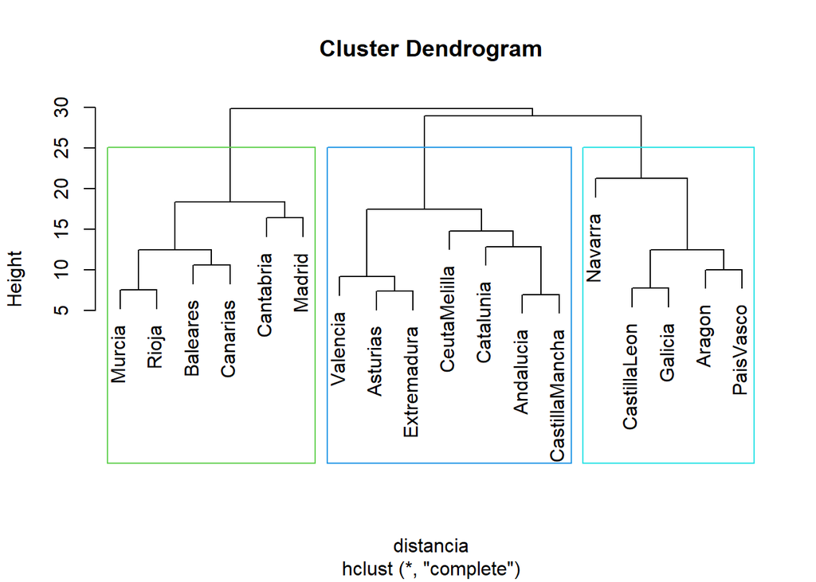

```r
jerarbas<-hclust(distancia, method = "complete")
plot(jerarbas)
rect.hclust(jerarbas, k = 3, border = 3:5)
```

Si utilizamos la funci´on cutree el ´arbol se corta para formar el n´umero de grupos deseado, que en este caso será 3

```r
arbol3<-cutree(jerarbas, k=3, h=NULL)
arbol3
```

```
##      Andalucia         Aragon       Asturias       Baleares       Canarias
##              1              2              1              3              3
##      Cantabria   CastillaLeon CastillaMancha      Catalunia       Valencia
##              3              2              1              1              1
##    Extremadura        Galicia         Madrid         Murcia        Navarra
##              1              2              3              3              2
##      PaisVasco          Rioja   CeutaMelilla
##              2              3              1
```

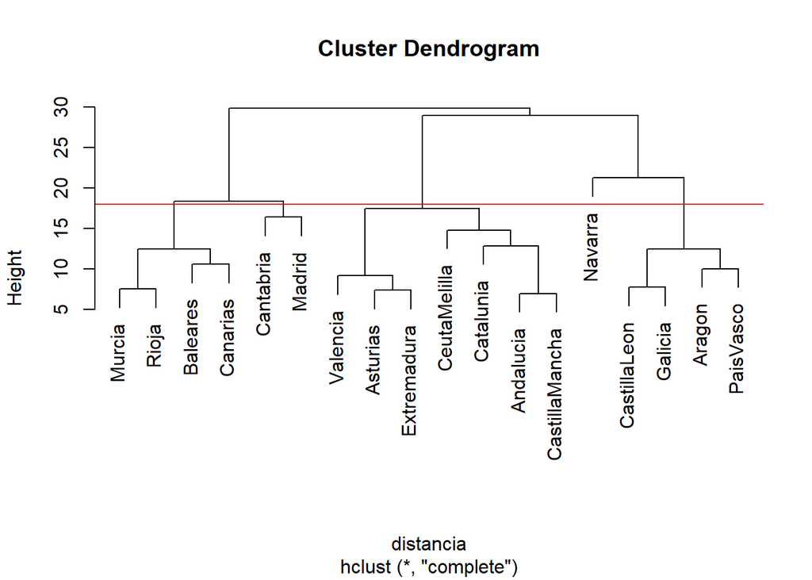

```r
plot(jerarbas)
abline(h = 18, col = "red")
```

calcular el coeficiente de correlaci´on cofen´etico utilizamos

```r
cor(distancia, cophenetic(jerarbas))
```

```
## [1] 0.4839919
```

Ahora calculamos otros metodos de agrupamiento:

```r
jeraravg<-hclust(distancia, method = "average")
jerarsin<-hclust(distancia, method = "single")
jerarwar<-hclust(distancia, method = "ward")
```

```
## The "ward" method has been renamed to "ward.D"; note new "ward.D2"
```

```r
# vector de metodos para comparar
m <- c( "average", "single", "ward")
#m <- c( jeraravg, jerarsin, jerarwar)
names(m) <- c( "average", "single", "ward")

# function to compute coefficient
print ('Promedio')
```

```
## [1] "Promedio"
```

```r
ac1 <-  cor(distancia, cophenetic(jeraravg))
ac1
```

```
## [1] 0.71799
```

```r
print ('Simple')
```

```
## [1] "Simple"
```

```r
ac2 <-  cor(distancia, cophenetic(jerarsin))
ac2
```

```
## [1] 0.6403901
```

```r
print ('Ward')
```

```
## [1] "Ward"
```

```r
ac3 <-  cor(distancia, cophenetic(jerarwar))
ac3
```

```
## [1] 0.4252559
```

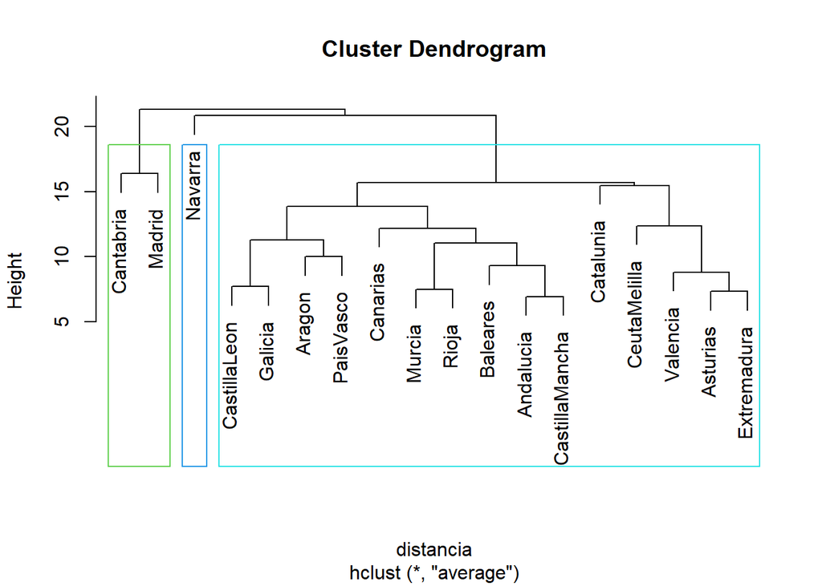

```r
jerarbas2<-hclust(distancia, method = "average")
plot(jerarbas2)
rect.hclust(jerarbas2, k = 3, border = 3:5)
```